# report

> Oleksandr Yuriichuk  
> Summer semester 2022/2023  
> Probability and Statistics 1, NMAI059

> Were used:
> - Python 3.10.8 with libraries: pandas, matplotlib, scipy, seaborn, numpy
> - [Data was obtained from CoinMarketCap](https://coinmarketcap.com/currencies/ethereum/historical-data/)

# Statistical Analysis Report

## Introduction

This report presents a statistical analysis of a dataset capturing Ethereum's price movement and associated trading metrics over 8 years, from its inception. The dataset encompasses variables such as opening price, closing price, daily high, daily low, trading volume, and market capitalization. The primary objective of this analysis is to delve into the data to identify patterns, relationships, and insights that might shed light on the various factors influencing Ethereum's price trajectory. Originating from a comprehensive record of daily trading data since Ethereum's launch, each entry in the dataset signifies a specific day's trading metrics. This comprehensive data provides a detailed view of the factors, like trading momentum and market sentiment, that could potentially sway Ethereum's market value. Through meticulous statistical techniques and data visualizations, this study seeks to address key questions, including:

- Is there a discernible correlation between specific months and Ethereum's price movement?
- Does trading volume have a significant bearing on the percentage change in Ethereum's price?
- Is there a specific time of day when Ethereum typically reaches its daily high or low price?

The goal of this analysis is to provide a clearer understanding of Ethereum's market behavior for traders, investors, and cryptocurrency enthusiasts. We'll start with some basic statistics, dive into visualization, and finally delve into hypothesis testing, concluding with a concise summary of our findings

## Dataset Overview

The dataset used in this analysis comprises Ethereum's daily trading data spanning over 8 years. Before diving into the statistical analysis, let's provide a brief overview of the dataset:

- **Total Number of Rows**: 2923
- **Total Number of Columns**: 11

**Dataset Columns**:

1. **timeOpen**: Start time of the trading day.
2. **timeClose**: End time of the trading day.
3. **timeHigh**: Time during the day when the highest price was reached.
4. **timeLow**: Time during the day when the lowest price was achieved.
5. **open**: Opening price of Ethereum for the day.
6. **high**: Highest price of Ethereum for the day.
7. **low**: Lowest price of Ethereum for the day.
8. **close**: Closing price of Ethereum for the day.
9. **volume**: Total trading volume of Ethereum for the day.
10. **marketCap**: Market capitalization of Ethereum for the day.
11. **timestamp**: Date and time corresponding to the data.

## Descriptive Statistics:

```python
# Imports
import pandas as pd
import matplotlib.pyplot as plt
import scipy.stats as stats
import seaborn as sns
import numpy as np
import matplotlib.gridspec as gridspec
from scipy.stats import kstest

data = pd.read_csv('EthereumHistoricalPriceDataset.csv')
```

```python
# Open price
mean_open = data['open'].mean()
median_open = data['open'].median()
min_open = data['open'].min()
max_open = data['open'].max()

print("Open price:")
print("Mean open price:", mean_open)
print("Median open price:", median_open)
print("Minimum open price:", min_open)
print("Maximum open price:", max_open)
```

```
Open price:
Mean open price: 876.4297349060255
Median open price: 299.53599545
Minimum open price: 0.431589007
Maximum open price: 4810.071533
```

```python
# High price
mean_high = data['high'].mean()
median_high = data['high'].median()
min_high = data['high'].min()
max_high = data['high'].max()

print("High price:")
print("Mean high price:", mean_high)
print("Median high price:", median_high)
print("Minimum high price:", min_high)
print("Maximum high price:", max_high)
```

```
High price:
Mean high price: 902.9433528727957
Median high price: 309.18000795
Minimum high price: 0.482988
Maximum high price: 4891.704698
```

```python
# Low price
mean_low = data['low'].mean()
median_low = data['low'].median()
min_low = data['low'].min()
max_low = data['low'].max()

print("Low price:")
print("Mean low price:", mean_low)
print("Median low price:", median_low)
print("Minimum low price:", min_low)
print("Maximum low price:", max_low)
```

```
Low price:
Mean low price: 846.9153151676136
Median low price: 291.01899975000003
Minimum low price: 0.420897007
Maximum low price: 4718.039256
```

```python
# Close price
mean_close = data['close'].mean()
median_close = data['close'].median()
min_close = data['close'].min()
max_close = data['close'].max()

print("Close price:")
print("Mean close price:", mean_close)
print("Median close price:", median_close)
print("Minimum close price:", min_close)
print("Maximum close price:", max_close)
```

```
Close price:
Mean close price: 876.8761881132939
Median close price: 299.98348999999996
Minimum close price: 0.434828997
Maximum close price: 4812.087614
```

```python
# Measures of Dispersion
std_open = data['open'].std()
range_open = data['open'].max() - data['open'].min()

print("Measures of Dispersion:")
print("\nOpen Price:")
print("Standard Deviation:", std_open)
print("Range:", range_open)

std_high = data['high'].std()
range_high = data['high'].max() - data['high'].min()

print("\nHigh Price:")
print("Standard Deviation:", std_high)
print("Range:", range_high)

std_low = data['low'].std()
range_low = data['low'].max() - data['low'].min()

print("\nLow Price:")
print("Standard Deviation:", std_low)
print("Range:", range_low)

std_close = data['close'].std()
range_close = data['close'].max() - data['close'].min()

print("\nClose Price:")
print("Standard Deviation:", std_close)
print("Range:", range_close)
```

```
Measures of Dispersion:

Open Price:
Standard Deviation: 1093.8340675365457
Range: 4809.639943993

High Price:
Standard Deviation: 1126.007349222797
Range: 4891.22171

Low Price:
Standard Deviation: 1057.1092525300564
Range: 4717.618358993

Close Price:
Standard Deviation: 1093.486159818005
Range: 4811.652785003
```

```python
# Correlations
corr_open_close = data['open'].corr(data['close'])

print("Correlation Coefficients:")
print("\nOpen and Close Price:")
print("Correlation:", corr_open_close)

corr_high_low = data['high'].corr(data['low'])

print("\nHigh and Low Price:")
print("Correlation:", corr_high_low)
```

```
Correlation Coefficients:

Open and Close Price:
Correlation: 0.9982341558380685

High and Low Price:
Correlation: 0.9984127920630599
```

# Data Visualization:

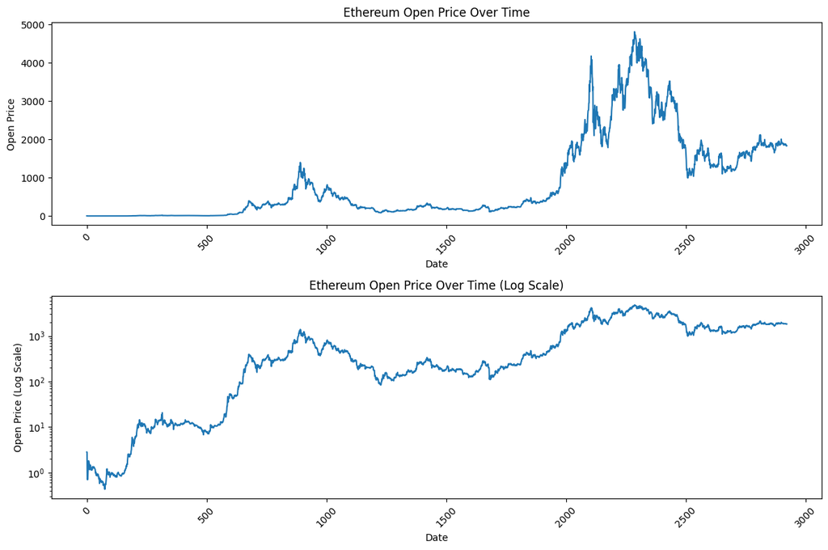

```python
fig, axs = plt.subplots(2, 1, figsize=(12, 8))

# Standard Ethereum chart
data['open'].plot(ax=axs[0], title='Ethereum Open Price Over Time')
axs[0].set_ylabel('Open Price')
axs[0].set_xlabel('Date')
axs[0].tick_params(axis='x', rotation=45)

# Logarithmic Ethereum chart
data['open'].plot(ax=axs[1], title='Ethereum Open Price Over Time (Log Scale)', logy=True)
axs[1].set_ylabel('Open Price (Log Scale)')
axs[1].set_xlabel('Date')
axs[1].tick_params(axis='x', rotation=45)

plt.tight_layout()
plt.show()
```

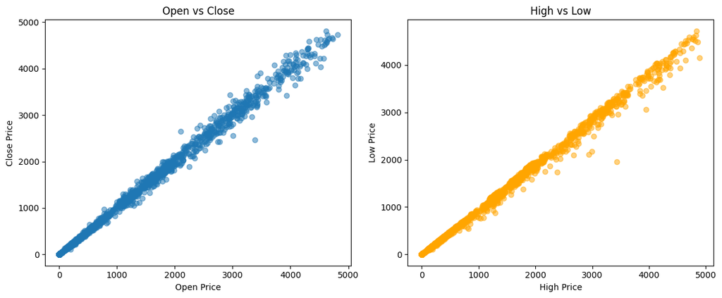

```python
fig, (ax1, ax2) = plt.subplots(1, 2, figsize=(12, 5))  # 1 row, 2 columns

# Scatter plot for Open vs Close
ax1.scatter(data['open'], data['close'], alpha=0.5)
ax1.set_title('Open vs Close')
ax1.set_xlabel('Open Price')
ax1.set_ylabel('Close Price')

# Scatter plot for High vs Low
ax2.scatter(data['high'], data['low'], alpha=0.5, color='orange')
ax2.set_title('High vs Low')
ax2.set_xlabel('High Price')
ax2.set_ylabel('Low Price')

plt.tight_layout()
plt.show()
```

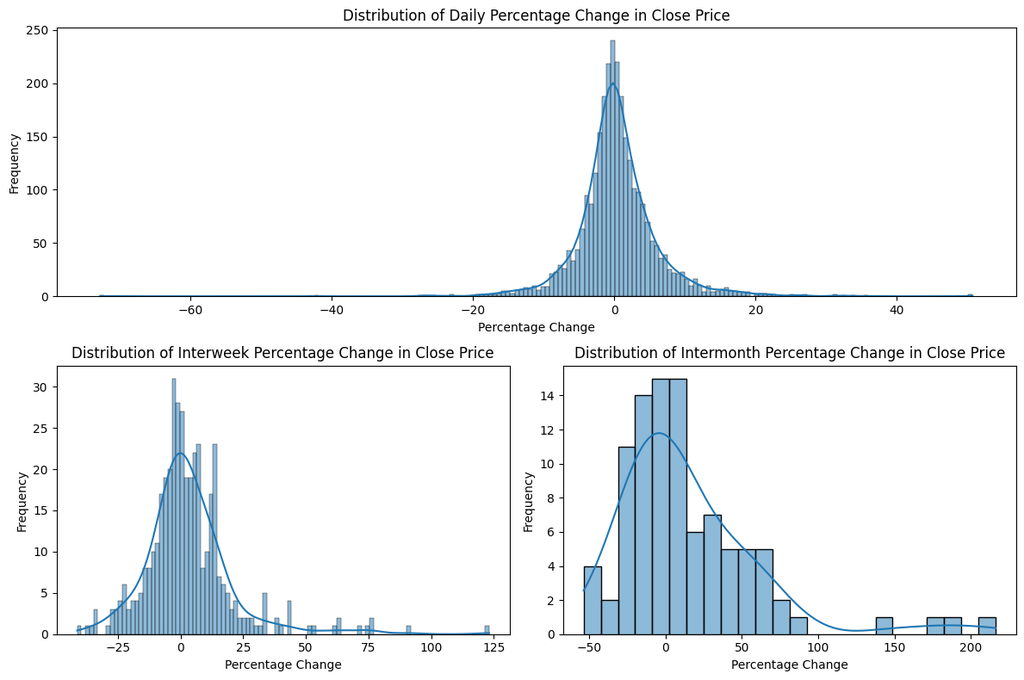

```python
fig = plt.figure(figsize=(12, 8))
gs = gridspec.GridSpec(2, 2, width_ratios=[1, 1])

# Convert the 'timeOpen' column to datetime
data['timeOpen'] = pd.to_datetime(data['timeOpen'])

# Daily distribution on the full top row
ax1 = plt.subplot(gs[0, :])
data['daily_pct_change'] = data['close'].pct_change() * 100
sns.histplot(data=data, x='daily_pct_change', kde=True, bins=200, ax=ax1)
ax1.set_title('Distribution of Daily Percentage Change in Close Price')
ax1.set_xlabel('Percentage Change')
ax1.set_ylabel('Frequency')

# Weekly distribution on the bottom left cell
ax2 = plt.subplot(gs[1, 0])

# Set the 'timeOpen' column as the index
data.set_index('timeOpen', inplace=True)

# Resample to get the last value of 'close' for each week ending on Sunday
weekly_closing_prices = data['close'].resample('W-SUN').last()
weekly_pct_change = weekly_closing_prices.pct_change() * 100
sns.histplot(weekly_pct_change.dropna(), kde=True, bins=100, ax=ax2)
ax2.set_title('Distribution of Interweek Percentage Change in Close Price')
ax2.set_xlabel('Percentage Change')
ax2.set_ylabel('Frequency')
data.reset_index(drop=False, inplace=True)
# Monthly distribution on the bottom right cell
ax3 = plt.subplot(gs[1, 1])

# Group by year and month from 'timeOpen' and get the last available data for each month
monthly_closing_prices = data.groupby([data['timeOpen'].dt.year, data['timeOpen'].dt.month])['close'].last()
monthly_pct_change = monthly_closing_prices.pct_change() * 100
sns.histplot(monthly_pct_change.dropna(), kde=True, bins=24, ax=ax3)
ax3.set_title('Distribution of Intermonth Percentage Change in Close Price')
ax3.set_xlabel('Percentage Change')
ax3.set_ylabel('Frequency')

plt.tight_layout()
plt.show()
```

# Hypothesis Testing

## Hypothesis 1: Correlation between specific months and Ethereum's price movement

We are interested in investigating if there's any discernible pattern in Ethereum's price movements when we look at it month-over-month across different years. While visualizations give a good initial perspective, statistical tests help in confirming or refuting such visual insights.

### Visual Analysis:

#### 1.1. Let's start by looking at a heatmap which showcases the monthly percentage change in Ethereum's price for each year.

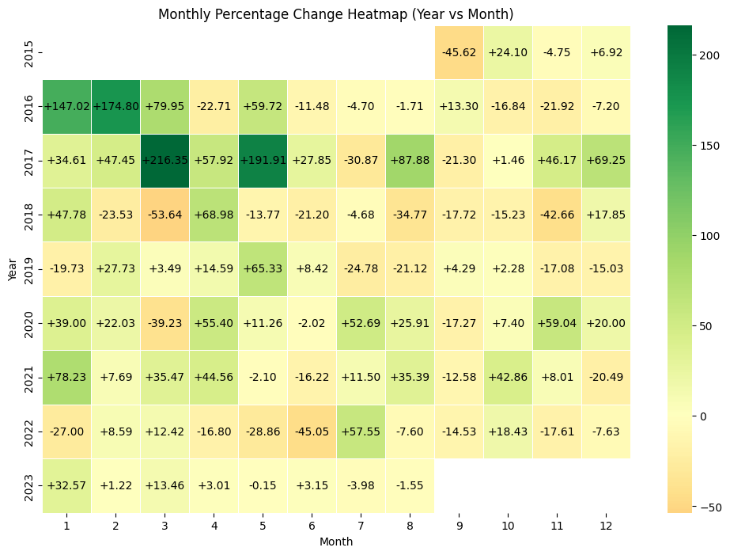

```python
# Create DataFrame from monthly_closing_prices and calculate percentage change
monthly_pct_change_df = monthly_closing_prices.to_frame()
monthly_pct_change_df['pct_change'] = monthly_pct_change_df['close'].pct_change() * 100

# Extract year and month from MultiIndex
monthly_pct_change_df['year'] = monthly_pct_change_df.index.get_level_values(0)
monthly_pct_change_df['month'] = monthly_pct_change_df.index.get_level_values(1)

# Pivot to create the heatmap data structure
pivot_pct_change = monthly_pct_change_df.pivot(index='year', columns='month', values='pct_change')

# Fill NaN values with a placeholder (e.g., 0) for visualization
pivot_pct_change_filled = pivot_pct_change.fillna(0)

# Visualize using a heatmap
plt.figure(figsize=(12, 8))
ax = sns.heatmap(pivot_pct_change, cmap="RdYlGn", center=0, linewidths=.5)

# Manually set annotations
for y in range(pivot_pct_change.shape[0]):
    for x in range(pivot_pct_change.shape[1]):
        value = pivot_pct_change.iloc[y, x]
        if not np.isnan(value):
            ax.text(x + 0.5, y + 0.5, '{:+.2f}'.format(value) if value > 0 else '{:.2f}'.format(value),
                    horizontalalignment='center',
                    verticalalignment='center')

plt.title('Monthly Percentage Change Heatmap (Year vs Month)')
plt.ylabel('Year')
plt.xlabel('Month')
plt.show()
```

### 1.2 Mean and Median Monthly Percentage Change

#### Next, we'll plot the mean and median monthly percentage changes to better understand the typical movement of Ethereum's price across different months.

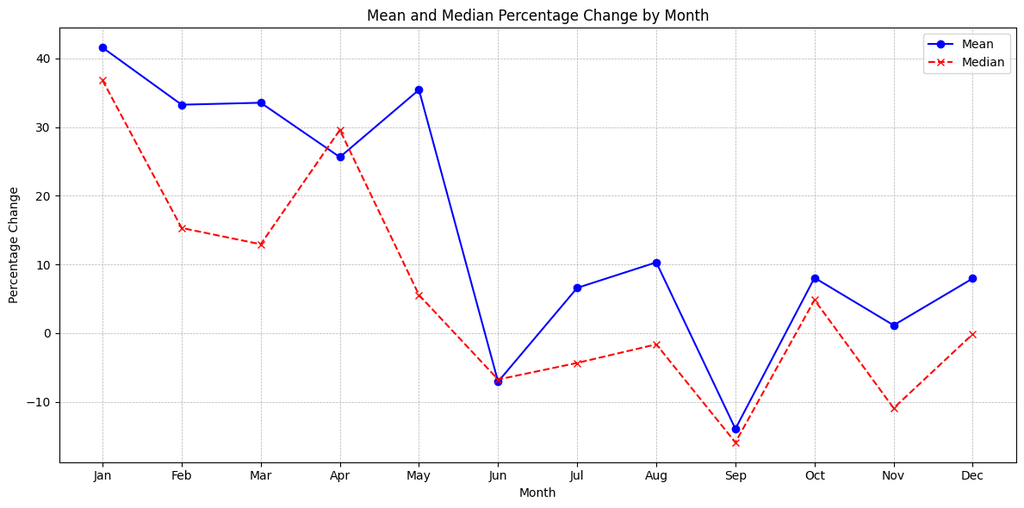

```python
# Group by month and calculate mean and median
monthly_stats = monthly_pct_change_df.groupby('month')['pct_change'].agg(['mean', 'median'])
# Plotting
months = ['Jan', 'Feb', 'Mar', 'Apr', 'May', 'Jun', 'Jul', 'Aug', 'Sep', 'Oct', 'Nov', 'Dec']

plt.figure(figsize=(12, 6))

# Mean Percentage Change
plt.plot(months, monthly_stats['mean'], marker='o', label='Mean', color='blue')

# Median Percentage Change
plt.plot(months, monthly_stats['median'], marker='x', linestyle='--', label='Median', color='red')

plt.title('Mean and Median Percentage Change by Month')
plt.xlabel('Month')
plt.ylabel('Percentage Change')
plt.legend()
plt.grid(True, which='both', linestyle='--', linewidth=0.5)
plt.tight_layout()
plt.show()
```

### 1.3 Statistical Analysis:

To quantitatively assess the possible monthly effects on Ethereum's price movement, we set out to statistically evaluate the monthly variations.

**Null Hypothesis (H0)**: The means of Ethereum's monthly percentage price changes are equal across all months. This would imply that there is no discernible monthly effect influencing Ethereum's price movement.

**Alternative Hypothesis (H1)**: At least one month has a mean percentage price change that is different from the other months. This would suggest that certain months may have a unique effect on Ethereum's price movement.

To test these hypotheses, a One-Way Analysis of Variance (ANOVA) test is appropriate. ANOVA can determine whether there are any statistically significant differences between the means of several independent groups. In this context, our independent groups are the months, and our dependent variable is the percentage price change of Ethereum.

By performing the One-Way ANOVA, we'll be comparing the variability between the monthly groups to the variability within each month. A significant result would indicate that the monthly factor has a notable influence on Ethereum's price movement, warranting further investigation to pinpoint which specific months differ from the rest.

Let's set a significance level, say $α=0.05$, to judge the p-value obtained from the ANOVA test. A p-value less than $α$ would lead us to reject our null hypothesis in favor of the alternative.

```python
# Extract the month from the timestamp
# monthly_pct_change_df['month'] = monthly_pct_change_df.index.month

# List to store percentage changes grouped by month
grouped_data = [monthly_pct_change_df['pct_change'][monthly_pct_change_df['month'] == month].dropna() for month in range(1, 13)]
# Run One-Way ANOVA test
f_statistic, p_value = stats.f_oneway(*grouped_data)

print("One-Way ANOVA")
print("=============")
print("F value:", f_statistic)
print("p value:", p_value)

# Check significance
alpha = 0.05
if p_value < alpha:
    print("\nSince the p-value < alpha, we reject the null hypothesis.")
    print("There is a significant difference in Ethereum's price movements across different months.")
else:
    print("\nSince the p-value > alpha, we fail to reject the null hypothesis.")
    print("There isn't a significant difference in Ethereum's price movements across different months.")
```

```
One-Way ANOVA
=============
F value: 1.209644467445197
p value: 0.2935051872496953

Since the p-value > alpha, we fail to reject the null hypothesis.
There isn't a significant difference in Ethereum's price movements across different months.
```

## Hypothesis 2: Impact of Trading Volume on Price Percentage Change

We're interested in understanding if the trading volume of Ethereum has a significant effect on the percentage change in its price. A Pearson correlation test can be utilized to examine this relationship.

**Null Hypothesis (H0)**: There is no significant correlation between the trading volume of Ethereum and the percentage change in its price.

**Alternative Hypothesis (H1)**: There is a significant correlation between the trading volume of Ethereum and the percentage change in its price.

We'll conduct the correlation test and report the results, which will include the correlation coefficient and p-value. If the p-value is less than a predetermined significance level (e.g., 0.05), we'll reject the null hypothesis in favor of the alternative hypothesis.

```python
# Remove the first row from both columns to ensure equal lengths
daily_pct_change_aligned = data['daily_pct_change'][1:]
volume_aligned = data['volume'][1:]

# Perform Pearson correlation test on the aligned data
correlation_coefficient, p_value = stats.pearsonr(volume_aligned, daily_pct_change_aligned)

# Set the significance level
alpha = 0.05

# Print the results
print("Correlation Coefficient:", correlation_coefficient)
print("p-value:", p_value)
print()

# Check if the null hypothesis should be rejected
if p_value < alpha:
    print("Result: Reject the null hypothesis.")
    print("Conclusion: There is a significant correlation between the trading volume of Ethereum and the percentage change in its price.")
else:
    print("Result: Fail to reject the null hypothesis.")
    print("Conclusion: There is no significant correlation between the trading volume of Ethereum and the percentage change in its price.")
```

```
Correlation Coefficient: -0.022175445070381588
p-value: 0.23086463085158151

Result: Fail to reject the null hypothesis.
Conclusion: There is no significant correlation between the trading volume of Ethereum and the percentage change in its price.
```

### Let's also visualize this relationship using a scatter plot:

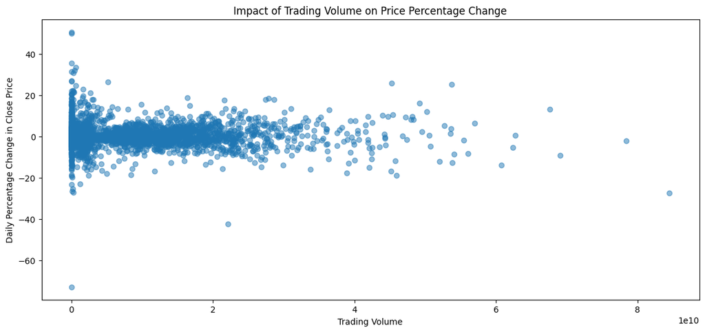

```python
# Scatter plot of volume vs daily_pct_change
plt.figure(figsize=(14, 6))
plt.scatter(data['volume'], data['daily_pct_change'], alpha=0.5)
plt.title('Impact of Trading Volume on Price Percentage Change')
plt.xlabel('Trading Volume')
plt.ylabel('Daily Percentage Change in Close Price')
plt.show()
```

## Hypothesis 3: Correlation between specific times of day and Ethereum's daily High or Low prices

Ethereum, like other cryptocurrencies, trades 24/7, making it immune to the opening or closing hours typical of traditional stock exchanges. However, it is conceivable that trading patterns or external events (like market openings in major financial centers) may influence the time of day when Ethereum hits its high or low price. We'll statistically and visually investigate this hypothesis

### Statistical Analysis:

To assess whether specific hours of the day significantly influence Ethereum's price peaks and troughs, we will compare the distributions of the times of day when these occur.

**Null Hypothesis (H0)**: The distribution of times when Ethereum reaches its daily high and low prices is uniform across all 24 hours of the day. This implies there isn't a specific hour of the day that is more likely to experience the high or low price of Ethereum.

**Alternative Hypothesis (H1)**: The distribution of times when Ethereum reaches its daily high and low prices is not uniform, suggesting certain hours are more likely to see Ethereum's high or low prices.

To test these hypotheses, the Kolmogorov-Smirnov test is appropriate. This test compares an observed sample distribution against a theoretical one, in this case, a uniform distribution. Since Ethereum trades around the clock, a uniform distribution would imply that every hour has an equal chance of being the hour when Ethereum hits its daily high or low price.

```python
# Assuming data is your DataFrame
data['timeHigh'] = pd.to_datetime(data['timeHigh'])
data['timeLow'] = pd.to_datetime(data['timeLow'])

# Extracting the hour from timeHigh and timeLow
data['hourHigh'] = data['timeHigh'].dt.hour
data['hourLow'] = data['timeLow'].dt.hour

# Performing the K-S test for High Prices
d_high, p_value_high = kstest(data['hourHigh'], 'uniform', args=(0,24))

print("Kolmogorov-Smirnov Test - High Prices")
print("======================================")
print("D statistic:", d_high)
print("p value:", p_value_high)

alpha = 0.05
if p_value_high < alpha:
    print("\nSince the p-value < alpha, we reject the null hypothesis.")
    print("The distribution of hours for High Prices is not uniform throughout the day.")
else:
    print("\nSince the p-value > alpha, we fail to reject the null hypothesis.")
    print("The distribution of hours for High Prices is uniform throughout the day.")

# Performing the K-S test for Low Prices
d_low, p_value_low = kstest(data['hourLow'], 'uniform', args=(0,24))

print("\nKolmogorov-Smirnov Test - Low Prices")
print("=====================================")
print("D statistic:", d_low)
print("p value:", p_value_low)

if p_value_low < alpha:
    print("\nSince the p-value < alpha, we reject the null hypothesis.")
    print("The distribution of hours for Low Prices is not uniform throughout the day.")
else:
    print("\nSince the p-value > alpha, we fail to reject the null hypothesis.")
    print("The distribution of hours for Low Prices is uniform throughout the day.")
```

```
Kolmogorov-Smirnov Test - High Prices
======================================
D statistic: 0.2637748117727584
p value: 6.4879007488218794e-180

Since the p-value < alpha, we reject the null hypothesis.
The distribution of hours for High Prices is not uniform throughout the day.

Kolmogorov-Smirnov Test - Low Prices
=====================================
D statistic: 0.22955167693360712
p value: 7.834432587957407e-136

Since the p-value < alpha, we reject the null hypothesis.
The distribution of hours for Low Prices is not uniform throughout the day.
```

### Visualization:

Our statistical findings indicate that the times when Ethereum hits its daily highs and lows are not uniformly distributed across the day. This naturally leads us to the question: which specific hours of the day are more prone to witnessing these highs and lows? Visualization becomes a powerful tool at this juncture, allowing us to discern discernible patterns or prevalent trends.

By plotting the distributions of times for daily highs and lows, we aim to provide a clearer representation of the periods during the day when Ethereum is most likely to reach its peak or trough values.

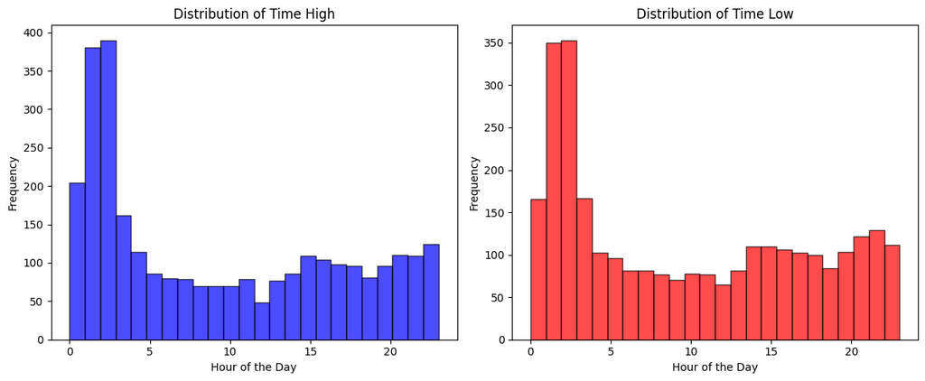

```python
# Extract time (hour) from timeHigh and timeLow
data['timeHigh'] = pd.to_datetime(data['timeHigh'])
data['timeLow'] = pd.to_datetime(data['timeLow'])
data["hourHigh"] = data["timeHigh"].dt.hour
data["hourLow"] = data["timeLow"].dt.hour

# Plot histogram
fig, axes = plt.subplots(nrows=1, ncols=2, figsize=(12, 5))

# Plot histogram for Time High
axes[0].hist(data["hourHigh"], bins=24, edgecolor='black', color='blue', alpha=0.7)
axes[0].set_title("Distribution of Time High")
axes[0].set_xlabel("Hour of the Day")
axes[0].set_ylabel("Frequency")

# Plot histogram for Time Low
axes[1].hist(data["hourLow"], bins=24, edgecolor='black', color='red', alpha=0.7)
axes[1].set_title("Distribution of Time Low")
axes[1].set_xlabel("Hour of the Day")
axes[1].set_ylabel("Frequency")

# Adjust layout
plt.tight_layout()
plt.show()
```

# Conclusion

## Descriptive Statistics

We delved into the dataset to uncover key insights about Ethereum's price dynamics. The essential takeaways are:

Price Volatility: The vast difference between the minimum and maximum values in Open, High, Low, and Close prices highlights Ethereum's significant volatility over the period. For instance, the Open Price ranged from a mere \$0.4316 to a towering $4810.07.

Strong Consistency Between Prices: The correlation coefficients reinforce the tight linkage between various price metrics. Specifically, the near-perfect correlation of 0.9982 between Open and Close Prices and 0.9984 between High and Low Prices underscores how intraday movements often culminate in similar opening and closing values.

Standard Deviation: The high standard deviations across all price categories, particularly with the Open Price deviating by approximately $1093.83 from its mean, emphasize the pronounced fluctuations in Ethereum's price.

In summary, our exploration reveals Ethereum's dynamic and volatile nature in its price movements, coupled with the inherent consistency between its opening and closing as well as high and low values.

## Hypothesis Testing

### Hypothesis 1: Correlation between specific months and Ethereum's price movement

Based on the provided mean percentage price change data across different months:

- January and May stand out with the highest positive percentage changes, implying bullish sentiments or favorable market conditions in these months.
- September, on the other hand, registers a substantial negative percentage change, indicating potential market corrections or bearish sentiments.

Despite these notable differences observed across months, the ANOVA test concluded that there isn't a statistically significant correlation between the specific month and Ethereum's price percentage change.

### Hypothesis 2: Impact of trading volume on price percentage change

A Pearson correlation test was conducted to determine the relationship between Ethereum's trading volume and its price percentage change. The outcome confirms the absence of a significant correlation between these two variables. This suggests that factors other than trading volume might be influencing Ethereum's price fluctuations.

### Hypothesis 3: Correlation between specific times of day and Ethereum's daily High or Low prices

The Kolmogorov-Smirnov test results validate a non-uniform distribution of hours for both daily High and Low prices of Ethereum. In other words, certain hours of the day are more likely to witness the day's peak or nadir prices than others.

Further breakdown of hourly data:

- **High Prices**: The early morning hours, specifically between 01:00 to 03:00, tend to register the highest frequency of daily highs.
- **Low Prices**: Similarly, the early morning hours, notably from 01:00 to 03:00, also frequently witness the day's lowest prices.

This pattern could be influenced by global trading activities, particularly in regions that become active during these hours. It underscores the importance of considering time zones and global markets when analyzing cryptocurrency price dynamics.

#### Conclusions:

Our hypothesis testing has unearthed several interesting facets of Ethereum's price behavior:

1. Ethereum's price movement does not have a consistent month-over-month pattern that can be deemed statistically significant.
2. The volume of Ethereum traded doesn't necessarily dictate its price change, hinting at a complex interplay of various other market forces.
3. The timing of daily highs and lows tends to cluster around specific hours, with the early morning hours being particularly significant.

This multifaceted analysis offers a more nuanced understanding of Ethereum's market dynamics, providing potential insights for traders and investors.

## Overall Conclusion

Concluding, Ethereum's price dynamics reveal a dance of volatility and patterns. While data offers valuable insights, the ever-evolving nature of Ethereum reminds traders and investors of the fluidity in the crypto landscape. Like watching ripples in water, discerning a definitive path is as challenging as it is intriguing.